# PetFinder.my Adoption prediction

### At last! An improvement.. Though small one..

This model is currently my best. There is much much more to be done, but I had to limit myself in the scope of the exercise due to time constraints. Our performance jumped from **0.358 --> 0.37**.

To sum up the model, I'll check the importances again:

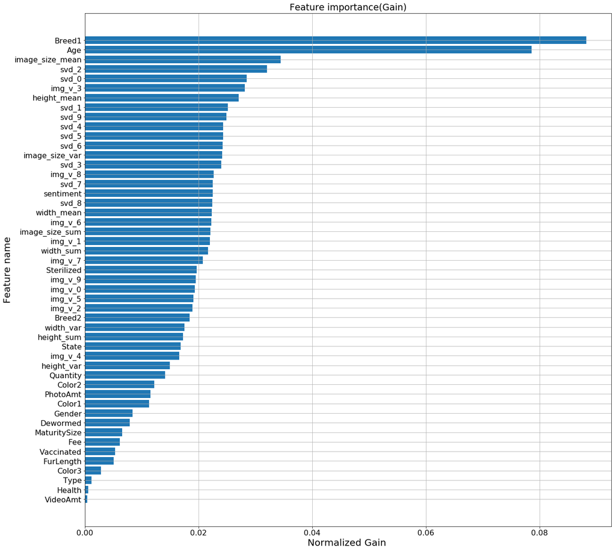

```python
PlotImportances(df_with_img_2, clf, 'gain')
```

### Every end is the beginning of something new...

In this (long) markdown cell i'll follow the rubric and recap/explain the chain of events. **Let's begin with the bottom line: At the beginning of the road, WITHOUT NLP (not seen in the notebook) the basic model scored 0.345. After all the goodies I managed to climb to 0.37.**

Having said that, let's go over the rubric:

#### Metodology

I'll elaborate about the feature engineering I did between steps and the initial and final results. Most of it was just adding/removing new columns of data that required different processing.

In between the steps, I changed between XGBoost to LightGBM (for faster training speeds) and attempted a lot of hyperparameters optimization, though I reached the conclusion it's hardly worth the time. Better invest in data manipulation.

#### Results - Model Evaluation and Validation

Model Evaluation and Validation: I chose to work with the LightGBM over the XGBoost model due to it's speed. (Much faster). As I explained in the background, this is an Ensemeble method which works via Gradient boosting.

I'll start with a **RECAP**:

1. In the course we learned about decision trees and creating boundaries for data classification via splitting the data in such a way that each step attempts to reduce the Entropy of the data (Gain information) via splitting the data in some manner.
2. We then advanced to Ensemble models. Decision trees tend to overfit, so we want to use many of them in some way for reduction in variance. We learned about Adaptive Boosting. It begins by fitting a weak classifier (say, decision tree), classifier on the original dataset and then fits additional copies of the classifier on the same dataset but where the weights of incorrectly classified instances (and thus, changes the sample distribution) are adjusted such that subsequent classifiers focus more on difficult cases.
3. Now, Gradient Boosting achieves the same goal (focusing on "harder/misclassified points") in a different manner. We fit a weak learner and observe the errors. We then continue to fit another weak learner, but this time **on the errors (residuals) themselves** and then add the result to our previous weak learner with some learning factor. This continues iteratevely and actually implements gradient descent because, for a squared error loss function, the residuals are the negative derivate, so adding a negative derivatie is a gradient descent step.
4. LightGBM/XGBoost are advanced implementations for the gradient boosting.

Let's discuss our final model qualities: It's a LightGBM model with the following parameters:

- Has max depth of 12 (No more splits beyond that).
- Learning rate (like in gradient descent) of 0.1.
- Feature fraction: The fraction of features selected for building a tree at each iteration (80%)
- Bagging fraction: The fraction of data used for each iteration. (85%)
- min_split_gain: Minimum loss reduction required to make a further partition on a leaf node of the tree. I chose 0.03.
- min_child_samples: The minimum number of points in a leaf or else won't split. I use a rather large value (200) in order to reduce overfitting.
- min_child_weight: From documentation: "Minimum sum of instance weight (hessian) needed in a child (leaf)". I'm not sure about this one.. :\

The important qualities of this model is:

1. It is an ensemble method that uses many "weak" classifiers to improve.
2. It can learn non-linear functions (based on decision trees).
3. It is also a super fast implementation.

The method I used to validate my results is both calculating the QWK score over the test set AND K-Fold cross validation. I also plotted the learning curve from which I could get a sense if the model is biased or overfitted. Unfortunately, it currently overfits. Simplifying it just degrades the training performance but doesn't improve the CV results.

#### Justification

A summary of my final results:

- **Training QWK: 0.71**
- **CV QWK: 0.37**
- **Test set QWK: 0.41**

The Kappa score is an [interesting metric](https://www.medcalc.org/manual/kappa.php). It measures accuracy of predicted labels, but then it also attempts to adjust for the probability of the algorithm and trusted labels assigning items to the same category "by chance". However, Kappa does not take into account the degree of disagreement between observers and all disagreement is treated equally as total disagreement. Therefore, when the categories are **ordered**, we use Weighted Kappa and assigns different weights $w_i$ to incorrect labels. How do we assing this weights? We use linear weights when the difference between the 1st and 2nd category has the same importance as a difference between the 2nd and 3rd category, etc. However, if the difference between the 1st and 2nd is less important than a difference between the 2nd and 3rd category, etc., we use quadratic weights.

**So it makes sense in our case. The more we "miss" the adoption waiting period, our prediction is worse.**

What do my results reflect?

##### why some approaches worked better than others?

What approaches worked well for me? And in contrast to what?

[figure not shown]

**OR** Perhaps the SVD dimensionality reduction had some impact. (Can't see why, since I tested many options and most of the data variability is explained in my selection)

**OR** It's just that the metadata, which is correlated to photo quality, is much more correlated to the adoption speed than just the content of the image.

**OR** Wrong network architecture, wrong features. I didn't actually test how these features looked.

1. Why did TF-IDF transformation worked better than embedding? I suspect this is because the distribution of words in the corpus of the embedded description matches the text descriptions less well than deriving a corpus from the descriptions themselves.
2. Why LightGBM worked better than XGBoost? It didn't! What it did was to train faster, and that's invaluable. The difference arises due to different implementations, but this is out of scope for this report.

##### Improvements

(To the tester: I added this part due to the comment in review: "`... and eventually make an Improvements section where you need to outline and discuss the potential improvements.`", however, I don't quite understand the difference between it and the "Improvement" section in the conclusion...)

==================================================================================================== The main improvement I would add would revolve around extracting more data from the images, because I think will have a high correlation to adoption speeds. Specifically:

- Add the metadata from the Google vision API, perform NLP on it as well if required.
- Attempt to combine features from multiple images.
- Attempt different NN architectures and feature extractions from different network layers.
- Attempt different types of classifiers (such as regression and than rounding to nearest time slot).
- I would spend less time on hyper parameter optimizations.

### Conclusion

#### Reflection

Let's recap the problem and end to end solution. We have dogs/cats data we want to predict the adoption speed. Our scoring method is based on QWK which is similar to accuracy. Our data is diverse (tabular, textual, metadata, images). The end to end solution contains:

1. Data exploration, correlations analysis, checking for problems in the data (Missing values, duplicates, etc.).
2. Building an ETL pipeline to convert and aggregate the data from numerous sources into pandas dataframe.
3. Training a GBM classifier over the data with iterations.
4. Between iterations, more data was added/removed, hyperparameters were updated in an attempt to improve the score. examples of improvements were written in the "results" section above.

There are 2 aspects of the projects which I found difficult and interesting:

1. The 1st is the entire Kaggle world. This is the 2nd time (1st one was for writing a data science blog using the [Deep Solar Dataset](https://www.kaggle.com/tunguz/deep-solar-dataset) i'm working on a dataset from there. Contrary to the 1st time where nobody handled that data yet, here I joined an active competition, a week before the deadline, with thousands of participants, experts, kernels, etc.. I was a bit overwhelmed by all the info, discussions and approaches for solving the problem and also the competitive edge. I ranked pretty lousy (though it wasn't my final model, didn't have time to support both this exercise and my kernel on Kaggle), but it opened my eyes to vast amount of data science and knowledge that can be gained through competitions. Moreover, I discovered that there are actually [courses](https://www.coursera.org/learn/competitive-data-science) aimed at teaching people how to win competitions.
2. Improving the classifier in iterations: It seemed that it's very hard to improve the models I built. Moreover, even when my model CV score improved, my public Kaggle score in the LB didn't improve and it was difficult to debug.
   - Which features do I use? Which ones I drop?
   - How much metadata to use?
   - What other external features (example: population size in states of Malesia?) should I bring.
   - When handling text, which embedding?
   - When handling images, which network?
   - ...

   It seems that these decisions are critical for utilizing my time effectively, and I need to develop a formal "strategy" for making these choices.

#### Improvement

There are **MANY MANY** improvements I considered applying, but didn't due to time constraints.

1. Utilizing more data out of the given one:
   - Use fields from json photos metadata.
   - Sentiment json file contains text regarding the photos. I wanted to add it to the NLP processing and TF-IDF.
   - I wanted to investigate more about extracting image features from the photos. Other networks, methods etc.
   - Using regressor estimators instead of classification and then rounding results.
   - Handling the imbalance in the data labels, attempting to match sample distribution to the public published test set.
   - ...
1. So, how would I change my implementation with the objective of scoring a higher QWK score?
   - I would concentrate all the extra data generation at the beginning of the code, after the ETL pipeline. (Current code adds more data along the way and it's annoying).
   - I would modify functions to support 2 types of input. Training/Testing. This would make it more easier for me to run an actual test set (not cross validations). (Because I added data along the way, inserting a test set data into the ETL pipeline isn't enough, I have to run more functions again.. This isn't the best implementation. I need a more ordered pipeline).
   - I would work directly in the Kaggle Kernel, or at least do regular copies from my local environment to the Kaggle kernel, test and commit there as well. (I currently developed only on my notebook and when attempting to develop on Kaggle, had to modify some parts of the code)
   - I would study the supplied test set and perform comparisons of distribution differences between it and the training data. (I didn't even check this currently, because my goal was to finish the capstone project, not winning the Kaggle competition).

## Final words

The exercise was a good training in supervised learning, data engineering and a difficult real world problem in a competitive environment. I feel that the Udacity Data Science course was a good intro into the field. Now it's just a matter of gaining experience and practicing more.

Thanks.

*Sammy K.*